# Time Series Project

Max Moro and Shane Weinstock

# Functions

```r
ase = function(f,x){
  mean((f - tail(x,length(f)))^2)
}
```

# Data Loading and Transformation

```r
#Loading data
data = readRDS('TO_cc_data.rds') %>%
  filter(snap_fiscal_month_sort >= 201001
         ,snap_fiscal_month_sort <= 201909) %>%
  rename(period = snap_fiscal_month_sort)  %>%
  arrange(period)
data$timeID = group_indices(data,period)
# Calculating Summaries
getSummary = function(x){x %>%
    summarise(separationsCount = sum(cnt_non_RIF_separations,na.rm=T)
              ,attritionRate = sum(cnt_non_RIF_separations,na.rm=T)/sum(headcount,na.rm=T)
              ,headcount = sum(headcount,na.rm=T)
              ,ageMeanYrs = sum(tot_age,na.rm=T)/sum(headcount,na.rm=T)/12
              ,tenureMeanYrs = sum(tot_tenure,na.rm=T)/sum(headcount,na.rm=T)/12
              ,recognitionEvents = sum(spot_events+points_events+star_events,na.rm=T)
              ,recognitionEventsMean = recognitionEvents / headcount
              ,supervisorsCount = sum(cnt_spvs,na.rm=T)
              ,workersPerSupervisor = headcount / supervisorsCount
              ,lowPerfCount = sum(tot_ppa_low,na.rm=T)
              ,lowPerfRate = lowPerfCount / headcount
              ,highPerfCount = sum(tot_ppa_high,na.rm=T)
              ,highPerfRate = highPerfCount / headcount
              ,timeID = max(timeID)
    )
}
#calculating Totals
dataTot = data  %>%
  group_by(period) %>%
  getSummary() %>% ungroup()
#saving to X variable
x=dataTot$attritionRate
```

# 1 - Describe Data Set

The Data set represents the number of workers who coluntary left a company between 2010 and 2019. The data is real, but is anonymized to maintin the confidentiality of the company.

The business request is forecast the attrition rate for the entire company for the next 12 months.

The data set is composed by a single representation with multiple features that can be used to idenitify and build multi-variate models to better forecast the attrition trend.

The data set has the following columsn

[output not shown]

# 2 - The response from the Dataset

We selected the Variable **attritionRate** as our response, it represents the ratio of poeple who voluntary left the company per each month.

# 3 - The Scenario

Attrition is an important factor for the company as it operates in a very niche market, requiring workers with very advanced technical knowledge. Once an important worker left the company it takes many months to hire and train a replacement. The berst solution to the problem is to predict the trend of attrition and which factors are correlated. The company can operate on these factors to reduce the future attrition.

# 4 - MODELS

The models are trained with a dataset without the most recent 12 months, we will use this portion to test the model performance.

```r
TestSize = 12
```

## ARMA(3,2) s=3

### a. ACF and Spectral analysis

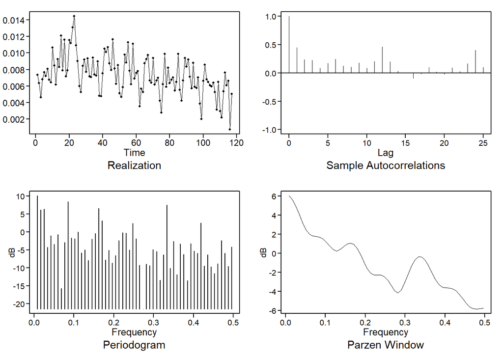

```r
p=tswge::plotts.sample.wge(x)
```

We have a wandering behavior on the realization. The ACF shows a quasi-cyclic behacior, hint of a seasonality in the data. The Parzen Window shows peaks at frequencies 0.17 and 0.34 (~6 and ~3 months).

Domain knowledge indicates that seasonality in expected, as people tend to voluntary leave the company during specific months (school ends, when financial results and bonuses are communicated). We are going to use a sesonality of **3 months** for this analysis.

### b. Check for seasonality

Let’s see if we have the s=3 or s=6 seasonality in the data

```r
tswge::factor.wge(phi=c(rep(0,5),1))
```

```
##
## Coefficients of Original polynomial:
## 0.0000 0.0000 0.0000 0.0000 0.0000 1.0000
##
## Factor                 Roots                Abs Recip    System Freq
## 1+1.0000B             -1.0000               1.0000       0.5000
## 1+1.0000B+1.0000B^2   -0.5000+-0.8660i      1.0000       0.3333
## 1-1.0000B+1.0000B^2    0.5000+-0.8660i      1.0000       0.1667
## 1-1.0000B              1.0000               1.0000       0.0000
##
##
```

```r
tswge::factor.wge(phi=c(rep(0,2),1))
```

```
##
## Coefficients of Original polynomial:
## 0.0000 0.0000 1.0000
##
## Factor                 Roots                Abs Recip    System Freq
## 1+1.0000B+1.0000B^2   -0.5000+-0.8660i      1.0000       0.3333
## 1-1.0000B              1.0000               1.0000       0.0000
##
##
```

```r
e=tswge::est.ar.wge(x,p=10,type='burg')
```

```
##
## Coefficients of Original polynomial:
## 0.4222 0.0058 0.1076 -0.1527 0.1406 0.1267 -0.0386 -0.0457 0.1534 -0.0412
##
## Factor                 Roots                Abs Recip    System Freq
## 1-0.8901B              1.1234               0.8901       0.0000
## 1+0.8992B+0.7544B^2   -0.5960+-0.9851i      0.8686       0.3366
## 1+1.4499B+0.6127B^2   -1.1832+-0.4818i      0.7828       0.4385
## 1-0.4676B+0.5989B^2    0.3904+-1.2318i      0.7739       0.2012
## 1-1.1211B+0.5712B^2    0.9814+-0.8874i      0.7558       0.1170
## 1-0.2924B              3.4196               0.2924       0.0000
##
##
```

we have a good evidence that the factors of **s=3** $(1-B^3)$ are present in the data. Frequencies fromm $(1-B^3)$ with value $0$ and $0.33$ are present in the data as 0,0 and 0.336, and the factors $(1-1B)$ and $(1+1B+1B^2)$ are present in the data as $(1-0.89B)$ and $(1-+0.8992B+0.754B^2)$.

Before proceeding with the aic5, we need to **remove the seasonality** ($s=3 months$)

```r
xtr=tswge::artrans.wge(x,phi.tr=c(rep(0,2),1))
```

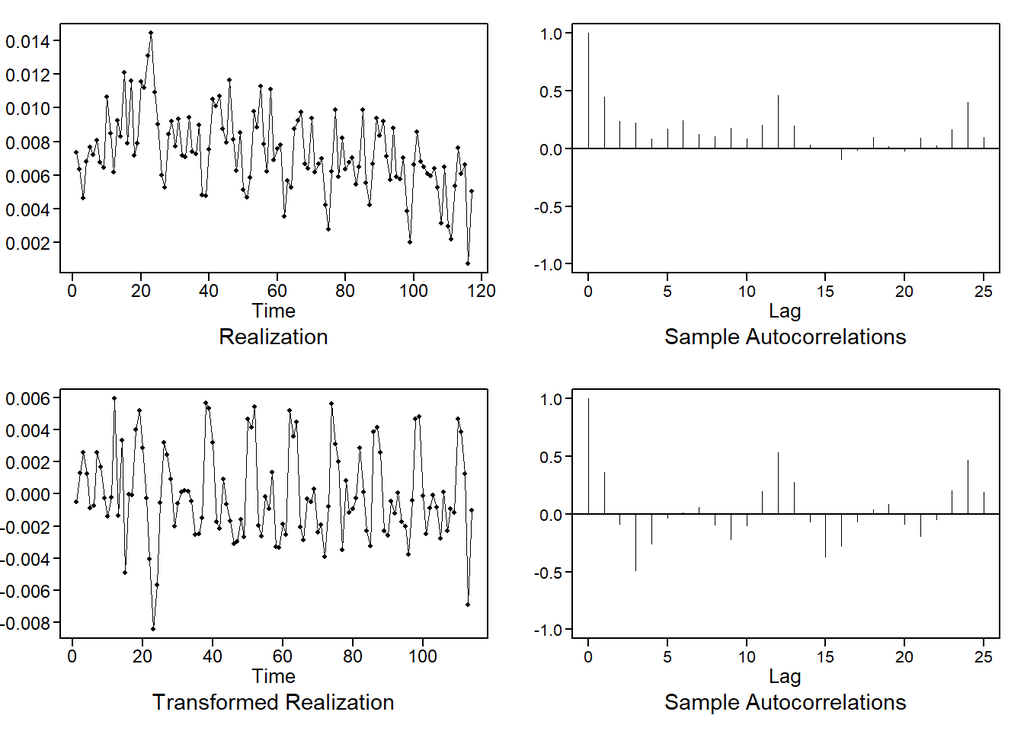

**ACF and Frequency after transformation**

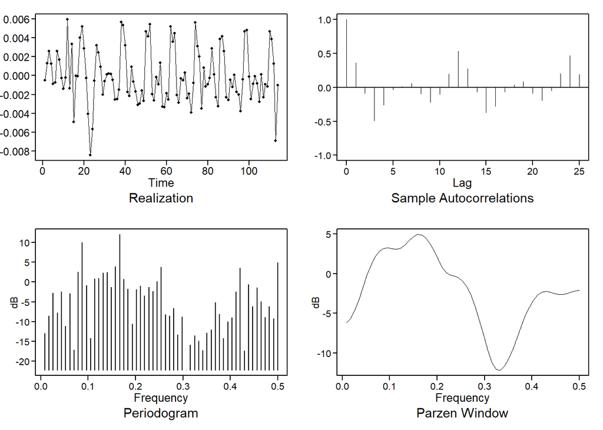

```r
p=tswge::plotts.sample.wge(xtr)
```

Now we can proceed with the aic5 by using the **xtr** variable

```r
aic5 = tswge::aic5.wge(xtr,p=0:5,q=0:3,type='aic')
```

```
## ---------WORKING... PLEASE WAIT...
##
##
## Five Smallest Values of  aic
```

```r
bic5 = tswge::aic5.wge(xtr,p=0:5,q=0:3,type='bic')
```

```
## ---------WORKING... PLEASE WAIT...
##
##
## Five Smallest Values of  bic
```

**Top 5 models using AIC**

|  | p | q | aic |
| --- | --- | --- | --- |
| 15 | 3 | 2 | -12.31923 |
| 19 | 4 | 2 | -12.15334 |
| 13 | 3 | 0 | -12.08547 |
| 17 | 4 | 0 | -12.07998 |
| 14 | 3 | 1 | -12.07800 |

**Top 5 models using BIC**

|  | p | q | bic |
| --- | --- | --- | --- |
| 15 | 3 | 2 | -12.17522 |
| 13 | 3 | 0 | -11.98946 |
| 19 | 4 | 2 | -11.98533 |
| 17 | 4 | 0 | -11.95997 |
| 14 | 3 | 1 | -11.95799 |

**PACF**

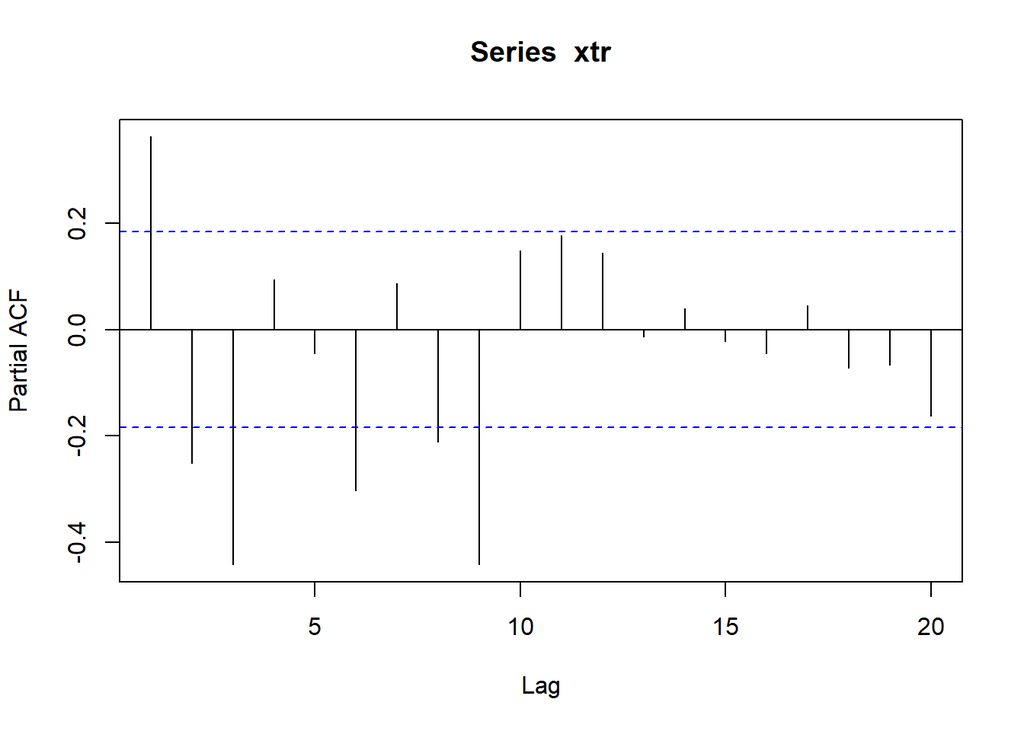

```r
pacf(xtr)
```

**ACF**

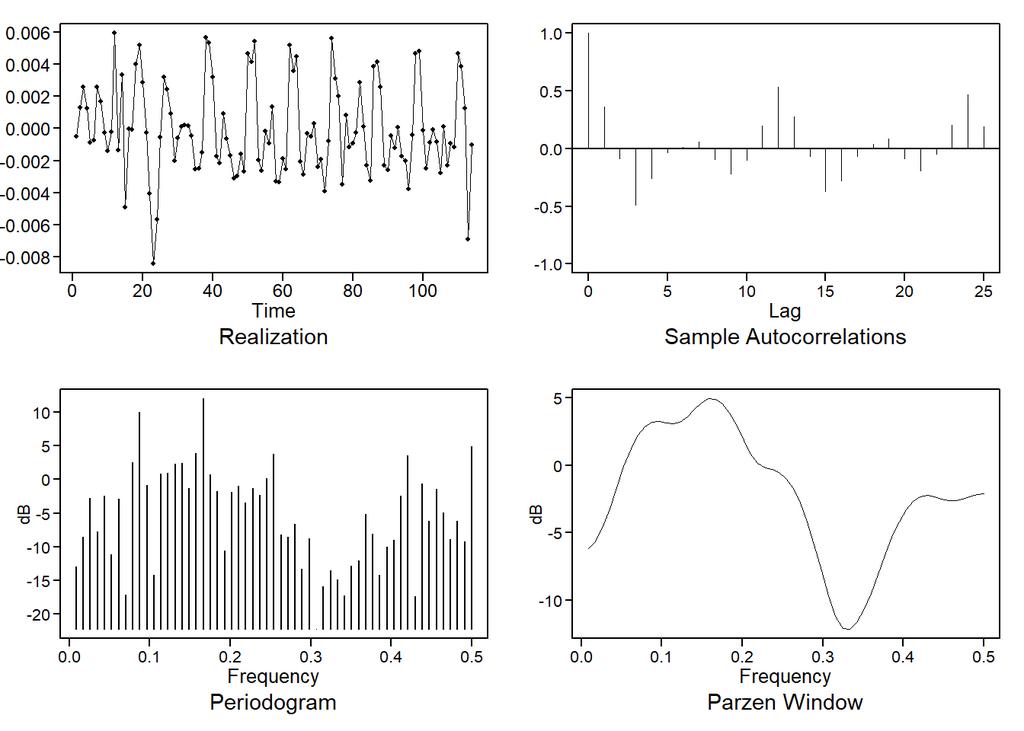

```r
p=tswge::plotts.sample.wge(xtr)
```

The PACF shows an erratic patern up to AR(9), we can’t be sure there is a pure AR model. The sample autocorrelation shows cycling pattern extending above the value of 0.5, so we should not have an MA only model

We are going to try following models

- ARMA(3,2) with seasonality of 3 months
- ARMA(4,2) with seasonality of 3 months
- AR(3) with seasonality of 3 months

### c. Factored Form

```r
p=3;q=2;s=3
es=tswge::est.arma.wge(xtr,p=p,q=q)
```

```
##
## Coefficients of Original polynomial:
## -0.3055 -0.2485 -0.2817
##
## Factor                 Roots                Abs Recip    System Freq
## 1-0.3211B+0.4496B^2    0.3571+-1.4479i      0.6705       0.2115
## 1+0.6265B             -1.5960               0.6265       0.5000
##
##
```

**Phis**

```r
es$phi
```

```
## [1] -0.3054536 -0.2484543 -0.2817179
```

```r
if(p>1) tswge::factor.wge(phi=es$phi)
```

```
##
## Coefficients of Original polynomial:
## -0.3055 -0.2485 -0.2817
##
## Factor                 Roots                Abs Recip    System Freq
## 1-0.3211B+0.4496B^2    0.3571+-1.4479i      0.6705       0.2115
## 1+0.6265B             -1.5960               0.6265       0.5000
##
##
```

**Thetas**

```r
es$theta
```

```
## [1] -0.9476180 -0.9634984
```

```r
if(q>1) tswge::factor.wge(phi=es$theta)
```

```
##
## Coefficients of Original polynomial:
## -0.9476 -0.9635
##
## Factor                 Roots                Abs Recip    System Freq
## 1+0.9476B+0.9635B^2   -0.4918+-0.8922i      0.9816       0.3302
##
##
```

```r
message('Variance: ',es$avar)
```

```
## Variance: 4.01893735243693e-06
```

```r
message('Mean: ',mean(x))
```

```
## Mean: 0.00734045018639848
```

$$(1-B^3)(1+0.3055B+0.2485B^2+0.2817B^3)(X_t-0.00734) = (1+0.9476B+0.9635B^2)a_t$$
$$\hat{\sigma}^2_a = 4.019*10^{-6}$$

### d. AIC

AIC for this model is -12.3192299

### e. ASE

```r
armaPred= tswge::fore.aruma.wge(x,phi = es$phi,theta = es$theta,s=s,n.ahead = TestSize,lastn = T)
```

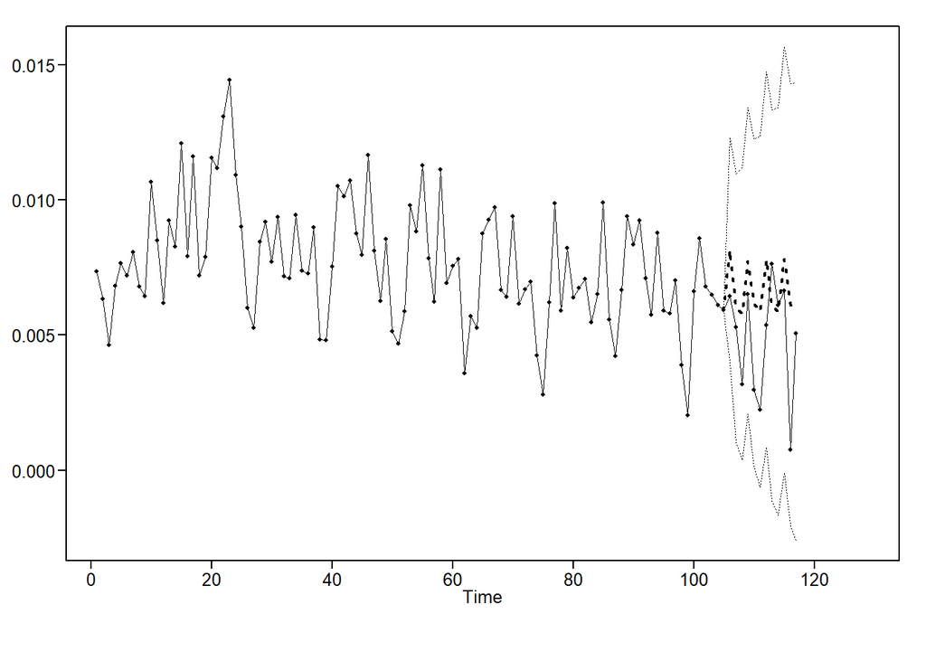

```r
armaASE = ase(armaPred$f,x)
```

The ASE of the model is 0.00000623

### f. Checking for Residuals

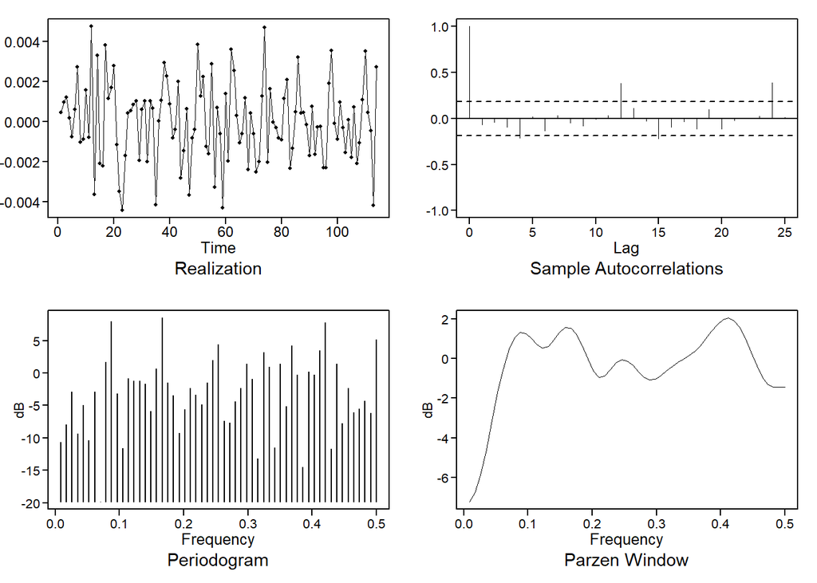

```r
armaRes = es$res
p=tswge::plotts.sample.wge(armaRes,arlimits = T)
```

```r
lj1=tswge::ljung.wge(armaRes,p=3,q=2,K=24)
```

```
## Obs -0.06357867 -0.04312625 -0.09235951 -0.2131672 0.02086215 -0.1349821 0.03082433 -0.04969529 -0.08136912 -0.007209264 0.03252114 0.3822347 0.1128903 -0.0300325 -0.2168407 -0.09492832 -0.03532005 -0.1163623 0.1013936 -0.1158533 -0.01836809 -0.0002378738 0.02603615 0.386626
```

```r
lj2=tswge::ljung.wge(armaRes,p=3,q=2,K=48)
```

```
## Obs -0.06357867 -0.04312625 -0.09235951 -0.2131672 0.02086215 -0.1349821 0.03082433 -0.04969529 -0.08136912 -0.007209264 0.03252114 0.3822347 0.1128903 -0.0300325 -0.2168407 -0.09492832 -0.03532005 -0.1163623 0.1013936 -0.1158533 -0.01836809 -0.0002378738 0.02603615 0.386626 0.01498631 -0.0199668…
```

```r
message('Ljung-Box Test with K=24 P-value = ',lj1$pval)
```

```
## Ljung-Box Test with K=24 P-value = 3.41361637845594e-07
```

```r
message('Ljung-Box Test with K=48. P-value = ',lj2$pval)
```

```
## Ljung-Box Test with K=48. P-value = 2.00875538425294e-09
```

## VAR

### a. Selecting multivariate data

As the attrition rate is a proportion of the headcount ($terminations / headcount$), we selected all the endogenous variables that are meaningful for the problem and are expressed as a rate of the headcount. This avoids using a variables that by design are correlated to the headcount (example: number of supervisors) instead of the attrition rate.

In addition, we noted that the recognition variable has data only for the past 2 years. We decided to remove this variable as it has too much missing data.

We specified a seasaonlity of 3 months as suggested by the ARMA model.

We are not specifying any exogenous variable as the company has no indication of future values for these variables.

```r
X=dataTot %>% dplyr::select(attritionRate,ageMeanYrs, tenureMeanYrs,  workersPerSupervisor, lowPerfRate, highPerfRate)


XTrain = head(X,nrow(X)-TestSize)
XTest  = tail(X,TestSize) #12 months
```

### b. Checking Cross Correlations

**Attrition and age**

```r
par(mfrow=c(2,3),mar=c(3,2,3,2))
with(XTrain,{
  ccf(attritionRate,ageMeanYrs)
  ccf(attritionRate,tenureMeanYrs)
  ccf(attritionRate,workersPerSupervisor)
  ccf(attritionRate,lowPerfRate)
  ccf(attritionRate,highPerfRate)
})
```

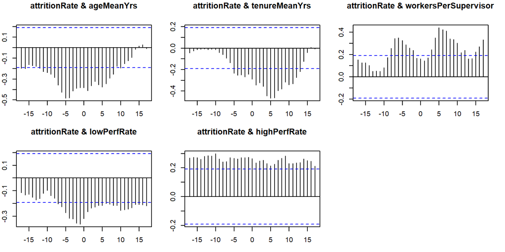

The most significant correlations with the Attrition Rate are **Mean Age** with lags of 5 and -5, **tenure** has a significant correlation with lag 6, also **workers per supervisor** has a correlation at lag 5. **Low Performers Ratio** is correlated with a lag of -2.

We can deduct the model may use lags up to 6.

```r
vars::VARselect(XTrain, lag.max = 7, type = 'trend',season = 3, exogen = NULL)
```

```
## $selection
## AIC(n)  HQ(n)  SC(n) FPE(n)
##      1      1      1      1
##
## $criteria
##                    1             2             3             4             5
## AIC(n) -4.386959e+01 -4.382713e+01 -4.371008e+01 -4.357754e+01 -4.339179e+01
## HQ(n)  -4.329346e+01 -4.286691e+01 -4.236578e+01 -4.184915e+01 -4.127932e+01
## SC(n)  -4.244522e+01 -4.145318e+01 -4.038655e+01 -3.930443e+01 -3.816910e+01
## FPE(n)  8.892668e-20  9.385099e-20  1.082760e-19  1.295970e-19  1.684328e-19
##                    6             7
## AIC(n) -4.324652e+01 -4.313721e+01
## HQ(n)  -4.074997e+01 -4.025657e+01
## SC(n)  -3.707426e+01 -3.601536e+01
## FPE(n)  2.185277e-19  2.877784e-19
```

### c. Model Training

We noticed the model has a better performance and overall behavior when using higher number of lags, with the optimal at lag=6.

```r
varFit=VAR(XTrain,p=6,type='trend',season=3,exogen=NULL)
summary(varFit$varresult$attritionRate)
```

```
##
## Call:
## lm(formula = y ~ -1 + ., data = datamat)
##
## Residuals:
##        Min         1Q     Median         3Q        Max
## -0.0040121 -0.0006429  0.0000276  0.0008147  0.0025459
##
## Coefficients:
##                           Estimate Std. Error t value Pr(>|t|)
## attritionRate.l1         1.804e-01  1.232e-01   1.464   0.1483
## ageMeanYrs.l1           -9.857e-04  2.341e-03  -0.421   0.6752
## tenureMeanYrs.l1        -3.770e-04  8.786e-04  -0.429   0.6694
## workersPerSupervisor.l1 -7.541e-04  1.914e-03  -0.394   0.6949
## lowPerfRate.l1          -2.980e-02  8.424e-02  -0.354   0.7248
## highPerfRate.l1          1.137e-02  2.065e-02   0.551   0.5839
## attritionRate.l2         5.770e-02  1.233e-01   0.468   0.6415
## ageMeanYrs.l2           -1.589e-03  2.708e-03  -0.587   0.5596
## tenureMeanYrs.l2         2.420e-03  1.180e-03   2.051   0.0447 *
## workersPerSupervisor.l2 -3.439e-03  2.370e-03  -1.451   0.1519
## lowPerfRate.l2           2.128e-01  1.257e-01   1.692   0.0957 .
## highPerfRate.l2         -5.448e-02  3.126e-02  -1.743   0.0865 .
## attritionRate.l3        -2.166e-01  1.217e-01  -1.781   0.0800 .
## ageMeanYrs.l3            3.225e-03  2.645e-03   1.219   0.2274
## tenureMeanYrs.l3        -4.366e-04  1.183e-03  -0.369   0.7134
## workersPerSupervisor.l3 -3.256e-03  2.163e-03  -1.505   0.1375
## lowPerfRate.l3          -7.080e-02  1.236e-01  -0.573   0.5688
## highPerfRate.l3          3.982e-03  3.138e-02   0.127   0.8994
## attritionRate.l4        -2.533e-03  1.215e-01  -0.021   0.9834
## ageMeanYrs.l4            2.974e-03  2.745e-03   1.083   0.2830
## tenureMeanYrs.l4        -3.095e-03  1.173e-03  -2.640   0.0106 *
## workersPerSupervisor.l4  1.726e-03  1.961e-03   0.880   0.3824
## lowPerfRate.l4          -4.287e-02  1.299e-01  -0.330   0.7426
## highPerfRate.l4          4.147e-02  3.213e-02   1.291   0.2017
## attritionRate.l5         1.827e-01  1.268e-01   1.440   0.1549
## ageMeanYrs.l5           -9.365e-04  2.879e-03  -0.325   0.7461
## tenureMeanYrs.l5         8.964e-04  1.130e-03   0.793   0.4309
## workersPerSupervisor.l5  2.599e-03  1.977e-03   1.315   0.1936
## lowPerfRate.l5           1.018e-01  1.334e-01   0.763   0.4484
## highPerfRate.l5         -3.895e-02  3.089e-02  -1.261   0.2121
## attritionRate.l6        -1.516e-01  1.129e-01  -1.343   0.1842
## ageMeanYrs.l6           -1.132e-03  2.363e-03  -0.479   0.6337
## tenureMeanYrs.l6        -1.099e-03  8.851e-04  -1.242   0.2190
## workersPerSupervisor.l6 -1.881e-03  1.513e-03  -1.244   0.2185
## lowPerfRate.l6          -2.178e-01  1.098e-01  -1.983   0.0520 .
## highPerfRate.l6          3.940e-02  2.039e-02   1.933   0.0580 .
## trend                   -4.449e-05  1.903e-05  -2.338   0.0228 *
## sd1                      2.835e-03  6.372e-04   4.449  3.8e-05 ***
## sd2                      1.109e-03  6.229e-04   1.781   0.0800 .
## ---
## Signif. codes:  0 '***' 0.001 '**' 0.01 '*' 0.05 '.' 0.1 ' ' 1
##
## Residual standard error: 0.001638 on 60 degrees of freedom
## Multiple R-squared:  0.9746, Adjusted R-squared:  0.9581
## F-statistic: 59.06 on 39 and 60 DF,  p-value: < 2.2e-16
```

We notice the model has a pvalue less than 0.05, hence we can reject the hypothesis the model is not significant

### d. AIC

The AIC of the model is -2590.5967406

**AIC**

```r
AIC(varFit)
```

```
## [1] -2590.597
```

### e. Model Testing Plot

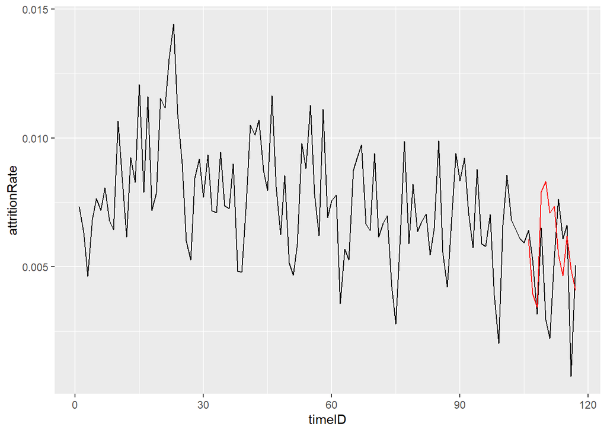

```r
varPred = predict(varFit,n.ahead=TestSize)
varPredFcst = varPred$fcst$attritionRate[,1]
varDataPred = cbind(dataTot,pred=NA)
varDataPred[(nrow(varDataPred)-TestSize+1):nrow(varDataPred),]$pred = varPredFcst
ggplot(data=varDataPred,aes(x=timeID,y=attritionRate)) +
  geom_line() +
  geom_line(aes(y=pred),color='red')
```

### f. ASE

```r
varASE = ase(varPredFcst,tail(dataTot,TestSize)$attritionRate)
```

The ASE of the model is 0.00000711

### g. Checking for residuals

[figure not shown]

```r
varRes  =varFit$varresult$attritionRate$residuals
p=tswge::plotts.sample.wge(varRes,arlimits = T)
```

## Neural Network

### a. Selecting multivariate data

We selected the same dataset used for the VAR section

```r
tsTrain = ts(XTrain,start=c(2010,1),frequency = 12)
tsTest = ts(XTest,start=c(2018,10),frequency = 12)
tsAll =   ts(rbind(XTrain,XTest),start=c(2010,1),frequency = 12)
```

### b. Model Training

We train the Nerual Network Model by using 20 repetitions and using a difforder of 1 and 3, to reflect the trend and the seasonality we found in previous models. We set lag search parameter from 1 to 6 to reflect the lag we found during the analysis for the VAR model

```r
set.seed(1701)
library(nnfor)
nnFit = nnfor::mlp(y=tsTrain[,'attritionRate'],reps=20
                   ,xreg = data.frame(tsAll[,colnames(tsAll) != 'attritionRate'])
                   ,difforder = c(1,3),hd.auto.type = 'cv',hd=NULL,lags=1:6)
nnFit
```

```
## MLP fit with 5 hidden nodes and 20 repetitions.
## Series modelled in differences: D1D3.
## Univariate lags: (1,2,3,4,6)
## 5 regressors included.
## - Regressor 1 lags: (2,3,4,5,6)
## - Regressor 2 lags: (2,3,5,6)
## - Regressor 3 lags: (1,5,6)
## - Regressor 4 lags: (2,3,5,6)
## - Regressor 5 lags: (2,3)
## Deterministic seasonal dummies included.
## Forecast combined using the median operator.
## MSE: 0.
```

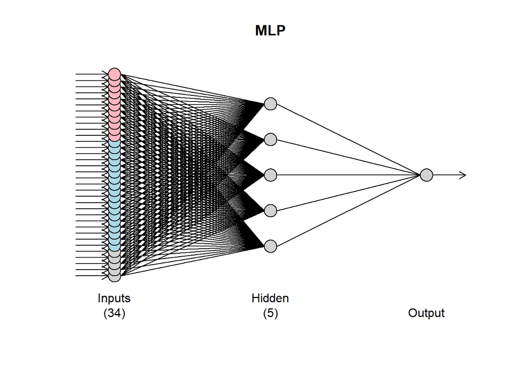

```r
plot(nnFit)
```

The Neural Network Model used 5 regressors with a different selection of lags.

### c. Model Testing Plot

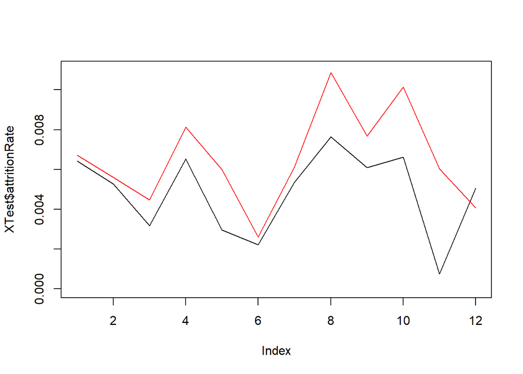

```r
nnTest=forecast(nnFit,h=TestSize,xreg = data.frame(tsAll[,colnames(tsAll) != 'attritionRate']))
plot(XTest$attritionRate,type='l',ylim =c(0,0.011))
lines(seq(1,TestSize),nnTest$mean,col='red')
```

### d. ASE

```r
nnASE = mean((tsTest[,'attritionRate'] - nnTest$mean)^2)
```

### e. Checking for residuals

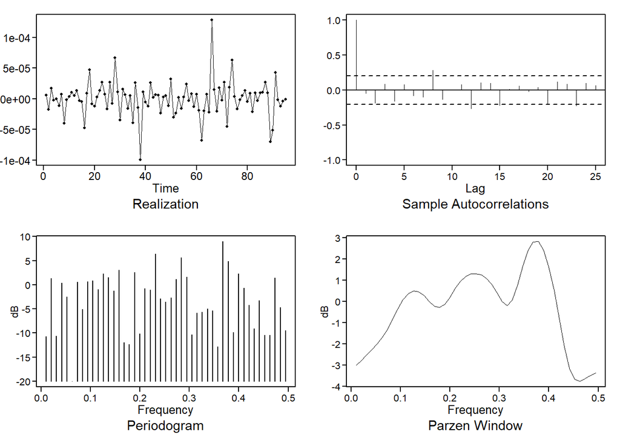

```r
nnRes  =nnTest$residuals
p=tswge::plotts.sample.wge(nnRes,arlimits = T)
```

## Ensamble

The Neural Network model has a great ASE performance, but it is not feasable for the business as we need to know the future values of the exogenous variables to calculate the attrition rate prediction. The business has no information about these future values. Furthermore, we cannot predict these valuas as is will increase the error rate and confidence interval.

So the best models for the business are VAR and ARMA(3,2).

We used a **Neural Network** algorithm to combine and improve the predictions of VAR and ARMA models. The model uses the predictions obtained from VAR and ARMA models as predictors, and the real attrition rate as target. This model can then be used to predit the future attrition values.

### a. Selecting Train and Test datasets

We used the first 2/3 of the train dataset to fit the VAR and ARMA models, then the last 1/3 of the train dataset to fit the **ensamble model** based on the output of the first two models. We will then use the test dataset (12 months) to measure the performance of the ensemble model.

```r
#https://www.analyticsvidhya.com/blog/2018/06/comprehensive-guide-for-ensemble-models/
ensTrain = head(XTrain,nrow(XTrain)*2/3)
ensTrain2  = tail(XTrain,nrow(XTrain)*1/3)
```

### b1. Base Models Training

```r
## ARMA Training from the 2/3 of train dataset
ensARMA= tswge::fore.aruma.wge(ensTrain$attritionRate
                               ,phi = es$phi,theta = es$theta,s=s
                               ,n.ahead = nrow(ensTrain2),lastn = F)
```

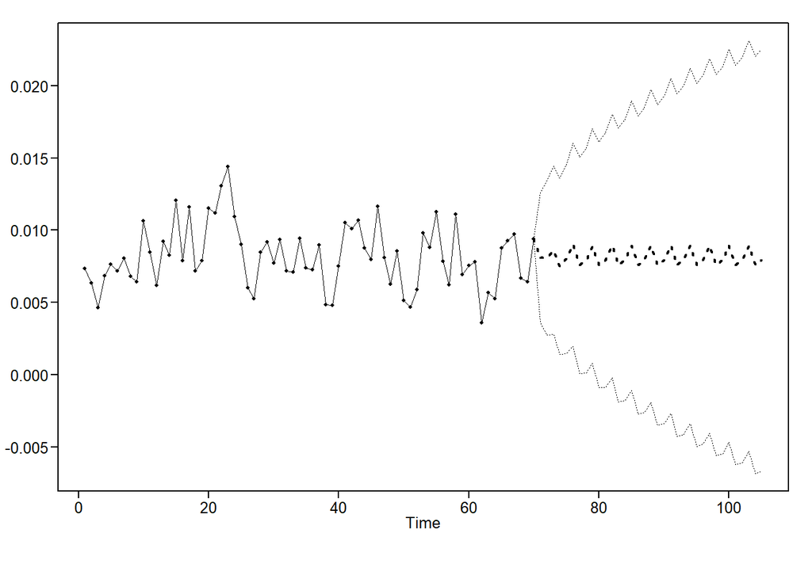

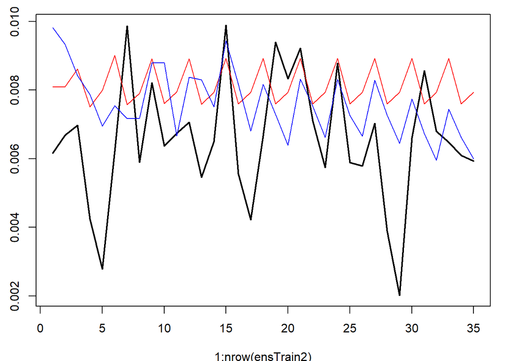

```r
ensARMAPred  = ensARMA$f

## VAR Training from  the 2/3 of train dataset
ensVAR= VAR(ensTrain,p=6,type='trend',season=3,exogen=NULL)
ensVARPred =  predict(ensVAR,n.ahead=nrow(ensTrain2))$fcst$attritionRate[,1]

## Plotting Predictions for the remaining 1/3 of the training dataset
plot(1:nrow(ensTrain2),ensTrain2$attritionRate, type='l',lwd=2)
lines(1:nrow(ensTrain2),ensARMAPred,col='red')
lines(1:nrow(ensTrain2),ensVARPred,col='blue')
```

We can see that the VAR prediction has a pattern similar to the prediction, while the ANOVA stays around the mean.

### b2. Ensemble Modeling

```r
## Training the ensambling (Neural Network Model)
set.seed(1701)
tsensTrain2 = tail(tsTrain,nrow(ensTrain2))
ensFit = nnfor::mlp(y=tsensTrain2[,'attritionRate'],reps=40
                    ,xreg = data.frame(ARMA = ts(ensARMAPred,start=min(time(tsensTrain2)),frequency=12)
                                       ,VAR = ts(ensVARPred,start=min(time(tsensTrain2)),frequency=12) )
                    ,difforder = NULL,hd.auto.type = 'cv',hd=NULL,lags=NULL)
ensFit
```

```
## MLP fit with 1 hidden node and 40 repetitions.
## Series modelled in differences: D1.
## Univariate lags: (2,12)
## 1 regressor included.
## - Regressor 1 lags: (9)
## Forecast combined using the median operator.
## MSE: 0.
```

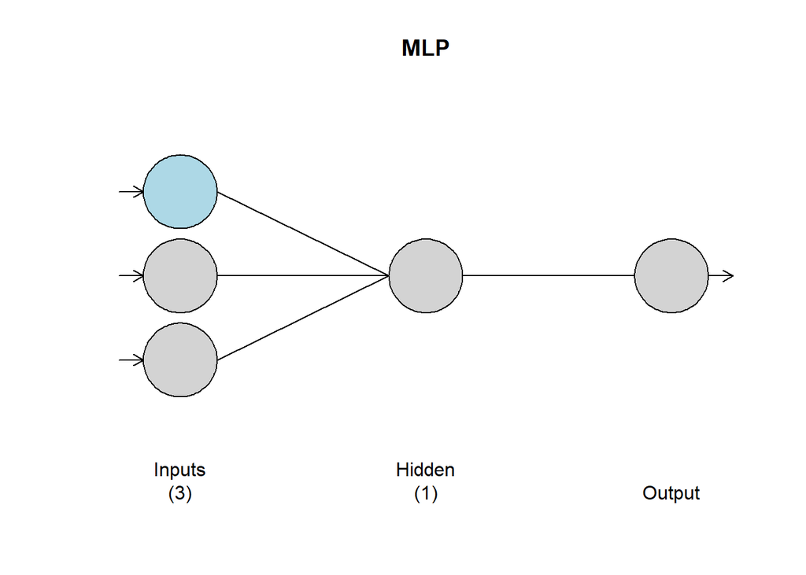

```r
plot(ensFit)
```

### c. Model Testing Plot

We are now proceeding to test the ensamble model for the Test dataset

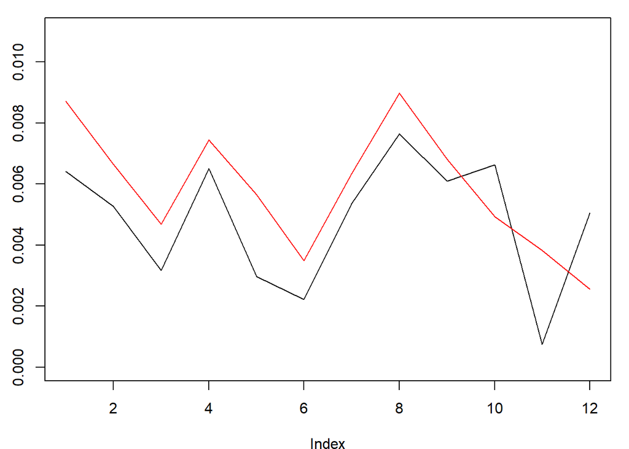

```r
#prediction from ARMA for the  test dataset
ensARMATestPred = tswge::fore.aruma.wge(XTrain$attritionRate
                               ,phi = es$phi,theta = es$theta,s=s
                               ,n.ahead =TestSize,lastn = F,plot=F)$f

#prediction from   for the  test dataset
ensVARTest= VAR(XTrain,p=6,type='trend',season=3,exogen=NULL)
ensVARTestPred =  predict(ensVAR,n.ahead=nrow(XTest))$fcst$attritionRate[,1]

#prediction from Ensemble (combining the predictions from ARMA and VAR)
ensTest=forecast(ensFit,h=TestSize,xreg =data.frame(
  ARMA = c(ensARMAPred, ensARMATestPred)
  ,VAR =  c(ensVARPred, ensVARTestPred)))
  #ARMA =  ts(c(ensARMAPred, ensARMATestPred),start=min(time(tsensTrain2)),frequency=12)
  #,VAR =  ts(c(ensVARPred, ensVARTestPred),start=min(time(tsensTrain2)),frequency=12)))
plot(XTest$attritionRate,type='l',ylim =c(0,0.011))
lines(seq(1,TestSize),ensTest$mean,col='red')
```

### d. ASE

```r
ensASE = mean((tsTest[,'attritionRate'] - ensTest$mean)^2)
```

### e. Checking for residuals

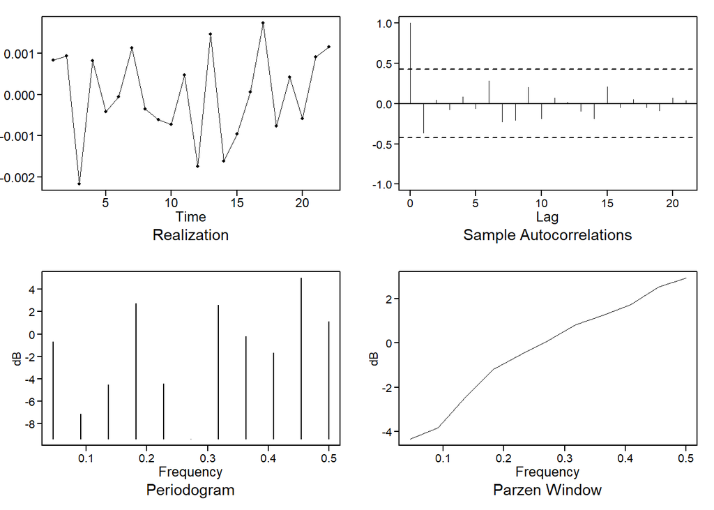

```r
nnRes  =ensTest$residuals
p=tswge::plotts.sample.wge(nnRes,arlimits = T)
```

The ASE of the ensemble model is 0.00000341

# 5. Comparing Models

| Model | ASE |
| --- | --- |
| ARMA(3,2) | 0.00000623 |
| VAR | 0.00000711 |
| Neural Network | 0.00000573 |
| Ensemble | 0.00000341 |

The ASE shows the Ensemble Model has the best Performance.

# 6. Forecast

We use a forecast horizon of 12 months, as it is most realisting intervention time for the company and the speed of the market it is operating in. We are also going to use the **Ensemble Model** to predict Future Values.

To run the ensamble model, we need first to create the predictions from the VAR and ARMA models, then we will use the fitted ensemble model to generate the future predictions.

NOTE: The package NNFOR doesn’t provide confidence intervals for MLP function [link](https://r.789695.n4.nabble.com/Confidence-Intervals-with-mlp-forecasts-td4758966.html). We will plot, instead, the predictions from all the runs of the Neural Network model.

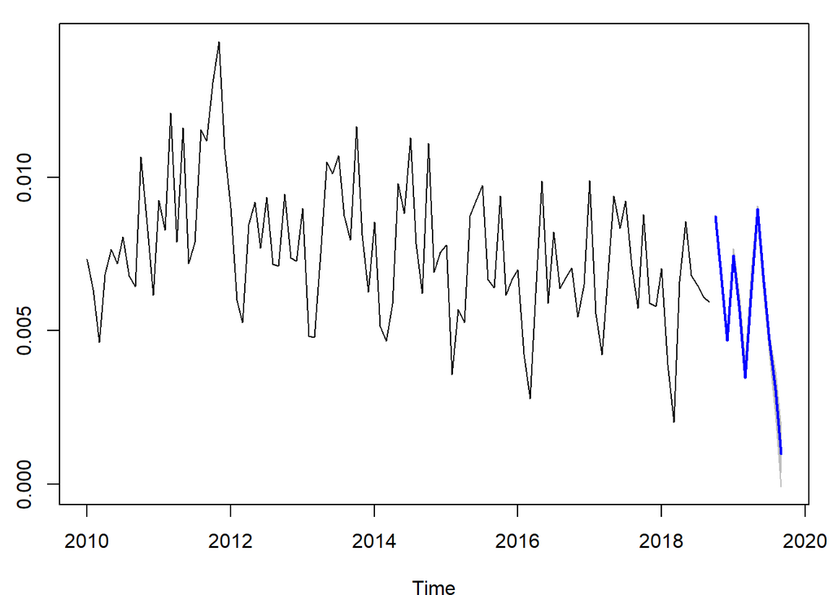

```r
horizon = 12
#prediction from ARMA
ensARMAFuturePred = tswge::fore.aruma.wge(X$attritionRate
                               ,phi = es$phi,theta = es$theta,s=s
                               ,n.ahead =horizon,lastn = F,plot=F)$f

#prediction from VAR
ensVARFuture = VAR(X,p=6,type='trend',season=3,exogen=NULL)
ensVARFuturePred =  predict(ensVARFuture,n.ahead=horizon)$fcst$attritionRate[,1]

#Ensamble model

##prediction from Ensemble
ensFuture=forecast(ensFit,h=TestSize,xreg =data.frame(
  ARMA =  c(ensARMAPred, ensARMAFuturePred)
  ,VAR =  c(ensVARPred, ensVARFuturePred))
  ,level=0.95)
#plot(ensFuture)
reps <- dim(ensFuture$all.mean)[2]
ts.plot(tsTrain[,'attritionRate'], ensFuture$all.mean, ensFuture$mean, col = c('black',rep("grey",reps), "blue"), lwd = c(1,rep(1, reps), 2))
```

```r
#showLast = 50
#plot(tail(X$attritionRate,showLast),type='l',xlim=c(1,showLast+horizon))
#lines((showLast+1):(horizon + showLast),ensFuture$mean,col='red')
#lines((showLast+1):(horizon + showLast),ensFuture$low,col='red')
```

We can see the forecast follows the pattern and sycles of the previous values, this is in line with the business expectations.